# fpp3-02

Author

Mikhael D. Manurung

## Chapter 2

```r
suppressPackageStartupMessages({
    library(fpp3)
    library(tidyverse)
    library(patchwork)
})
theme_set(theme_minimal())
```

# Q5

Download tourism.xlsx from the book website and read it into R using readxl::read_excel()

```r
tour <- openxlsx::read.xlsx("https://bit.ly/fpptourism")
head(tour)
```

```
     Quarter   Region           State  Purpose    Trips
1 1998-01-01 Adelaide South Australia Business 135.0777
2 1998-04-01 Adelaide South Australia Business 109.9873
3 1998-07-01 Adelaide South Australia Business 166.0347
4 1998-10-01 Adelaide South Australia Business 127.1605
5 1999-01-01 Adelaide South Australia Business 137.4485
6 1999-04-01 Adelaide South Australia Business 199.9126
```

```r
head(tsibble::tourism)
```

```
# A tsibble: 6 x 5 [1Q]
# Key:       Region, State, Purpose [1]
  Quarter Region   State           Purpose  Trips
    <qtr> <chr>    <chr>           <chr>    <dbl>
1 1998 Q1 Adelaide South Australia Business  135.
2 1998 Q2 Adelaide South Australia Business  110.
3 1998 Q3 Adelaide South Australia Business  166.
4 1998 Q4 Adelaide South Australia Business  127.
5 1999 Q1 Adelaide South Australia Business  137.
6 1999 Q2 Adelaide South Australia Business  200.
```

Create a tsibble which is identical to the tourism tsibble from the tsibble package.

```r
tour <- tour %>%
    mutate(Quarter = yearquarter(Quarter)) %>%
    as_tsibble(index = Quarter, key=c(Region, State, Purpose))

waldo::compare(tour, tourism)
```

```
        old$Trips          | new$Trips
[19889] 2.8169669000000002 | 2.8169669000000002 [19889]
[19890] 0.4674555000000000 | 0.4674555000000000 [19890]
[19891] 3.2478859999999998 | 3.2478859999999998 [19891]
[19892] 7.5454040000000004 - 7.5454039999999996 [19892]
[19893] 0.9179794000000000 | 0.9179794000000000 [19893]
[19894] 4.4062273000000003 | 4.4062273000000003 [19894]
[19895] 9.9572614999999995 | 9.9572614999999995 [19895]

        old$Trips            | new$Trips
[21572] 576.1470776999999543 | 576.1470776999999543 [21572]
[21573] 624.3241719999999759 | 624.3241719999999759 [21573]
[21574] 568.5222447999999531 | 568.5222447999999531 [21574]
[21575] 450.0508533000000284 - 450.0508532999999716 [21575]
[21576] 455.7709211000000096 | 455.7709211000000096 [21576]
[21577] 650.6406232000000500 | 650.6406232000000500 [21577]
[21578] 537.2495798999999579 | 537.2495798999999579 [21578]

        old$Trips           | new$Trips
[21781] 52.6686116999999996 | 52.6686116999999996 [21781]
[21782] 22.8965834000000008 | 22.8965834000000008 [21782]
[21783] 52.9925046999999978 | 52.9925046999999978 [21783]
[21784] 37.9477448999999964 - 37.9477449000000036 [21784]
[21785] 33.2958540999999997 | 33.2958540999999997 [21785]
[21786] 20.9812869000000006 | 20.9812869000000006 [21786]
[21787] 33.5120920999999967 | 33.5120920999999967 [21787]
```

Find what combination of Region and Purpose had the maximum number of overnight trips on average.

```r
tour %>%
    as_tibble() %>%
    group_by(Region, Purpose) %>%
    summarise(mean_trips = mean(Trips)) %>%
    ungroup() %>%
    slice_max(mean_trips, n=5)
```

```
# A tibble: 5 x 3
  Region          Purpose  mean_trips
  <chr>           <chr>         <dbl>
1 Sydney          Visiting       747.
2 Melbourne       Visiting       619.
3 Sydney          Business       602.
4 North Coast NSW Holiday        588.
5 Sydney          Holiday        550.
```

Create a new tsibble which combines the Purposes and Regions, and just has total trips by State.

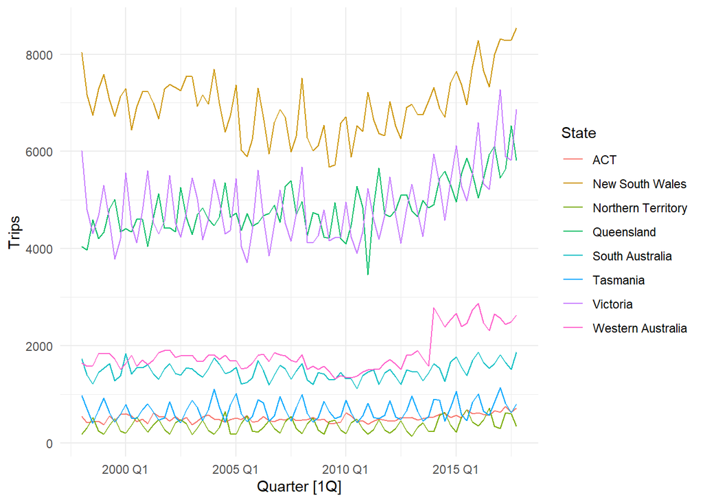

```r
tour %>%
    group_by(State) %>%
    summarise(Trips = sum(Trips)) %>%

    autoplot(Trips)
```

# Q9

Use the following graphics functions: `autoplot()`, `gg_season()`, `gg_subseries()`, `gg_lag()`, `ACF()` and explore features from the following time series: “Total Private” `Employed` from `us_employment`, `Bricks` from `aus_production`, `Hare` from `pelt`, “H02” `Cost` from `PBS`, and `us_gasoline`.

```
-   Can you spot any seasonality, cyclicity and trend?
-   What do you learn about the series?
-   What can you say about the seasonal patterns?
-   Can you identify any unusual years?
```

**US Employment**

**Data**

```r
head(us_employment)
```

```
# A tsibble: 6 x 4 [1M]
# Key:       Series_ID [1]
     Month Series_ID     Title         Employed
     <mth> <chr>         <chr>            <dbl>
1 1939 Jan CEU0500000001 Total Private    25338
2 1939 Feb CEU0500000001 Total Private    25447
3 1939 Mar CEU0500000001 Total Private    25833
4 1939 Apr CEU0500000001 Total Private    25801
5 1939 May CEU0500000001 Total Private    26113
6 1939 Jun CEU0500000001 Total Private    26485
```

```r
us_private <- us_employment %>%
    filter(Title == "Total Private")
```

**Time plot**

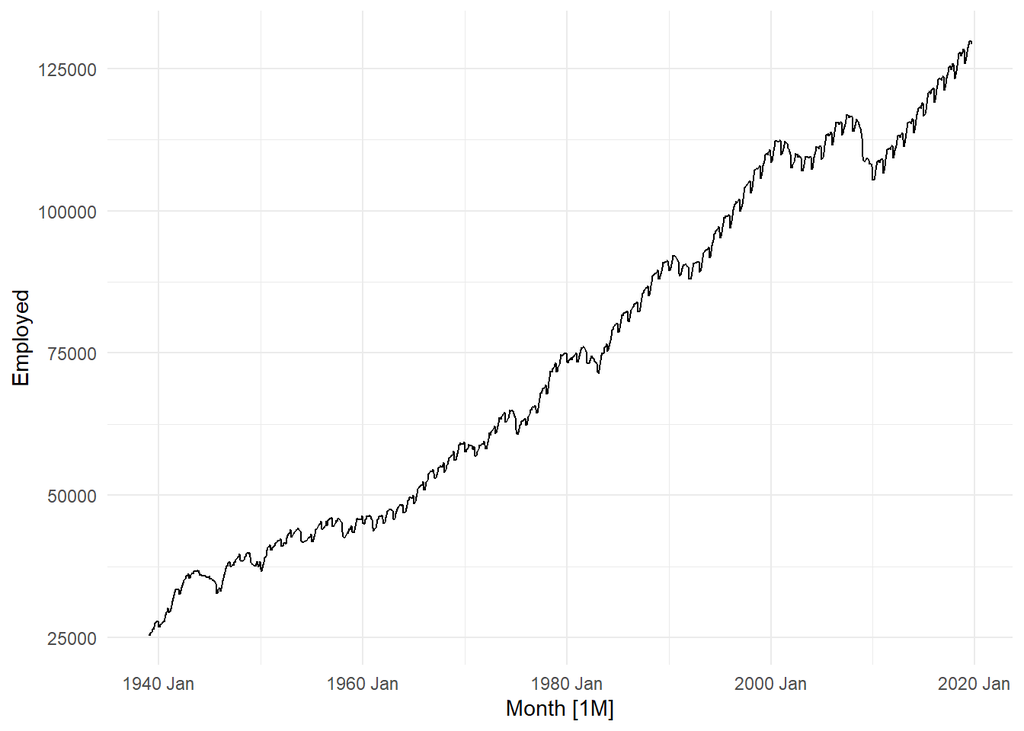

```r
##
us_private %>%
    autoplot(Employed)
```

**Seasonality**

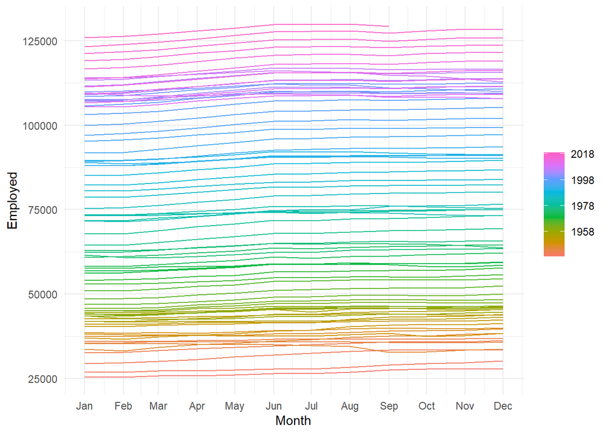

```r
##
us_private %>%
    gg_season(Employed)
```

**Sub-series**

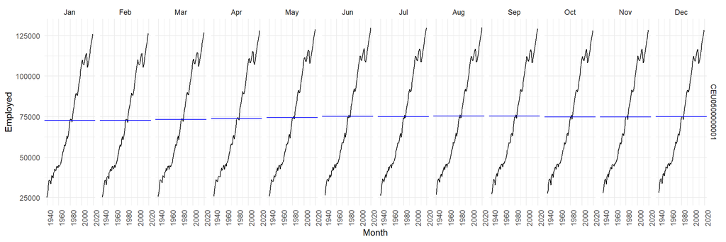

```r
##
us_private %>%
    gg_subseries(Employed)
```

**Lag**

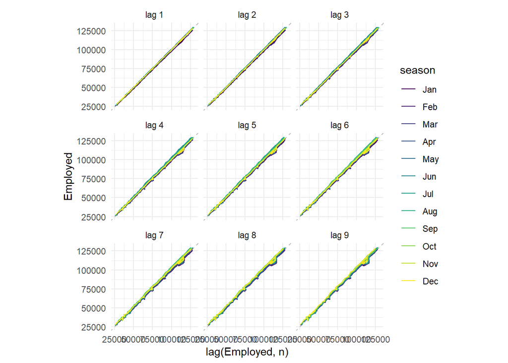

```r
us_private %>%
    gg_lag(Employed)
```

**Autocorrelation**

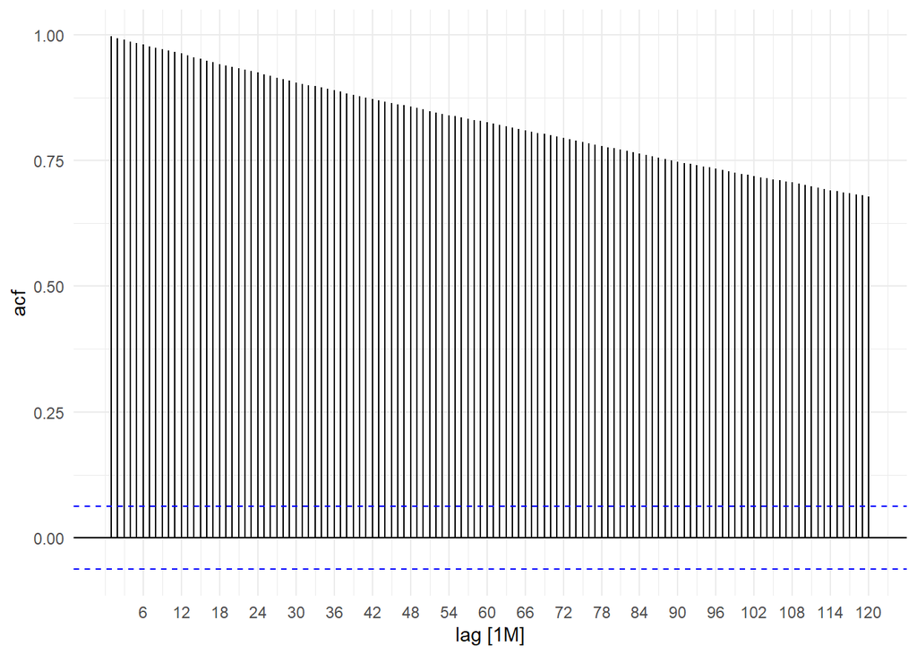

```r
us_private %>%
    ACF(Employed, lag_max=120) %>%
    autoplot()
```

**AUS Production**

**Data**

```r
head(aus_production)
```

```
# A tsibble: 6 x 7 [1Q]
  Quarter  Beer Tobacco Bricks Cement Electricity   Gas
    <qtr> <dbl>   <dbl>  <dbl>  <dbl>       <dbl> <dbl>
1 1956 Q1   284    5225    189    465        3923     5
2 1956 Q2   213    5178    204    532        4436     6
3 1956 Q3   227    5297    208    561        4806     7
4 1956 Q4   308    5681    197    570        4418     6
5 1957 Q1   262    5577    187    529        4339     5
6 1957 Q2   228    5651    214    604        4811     7
```

**Time plot**

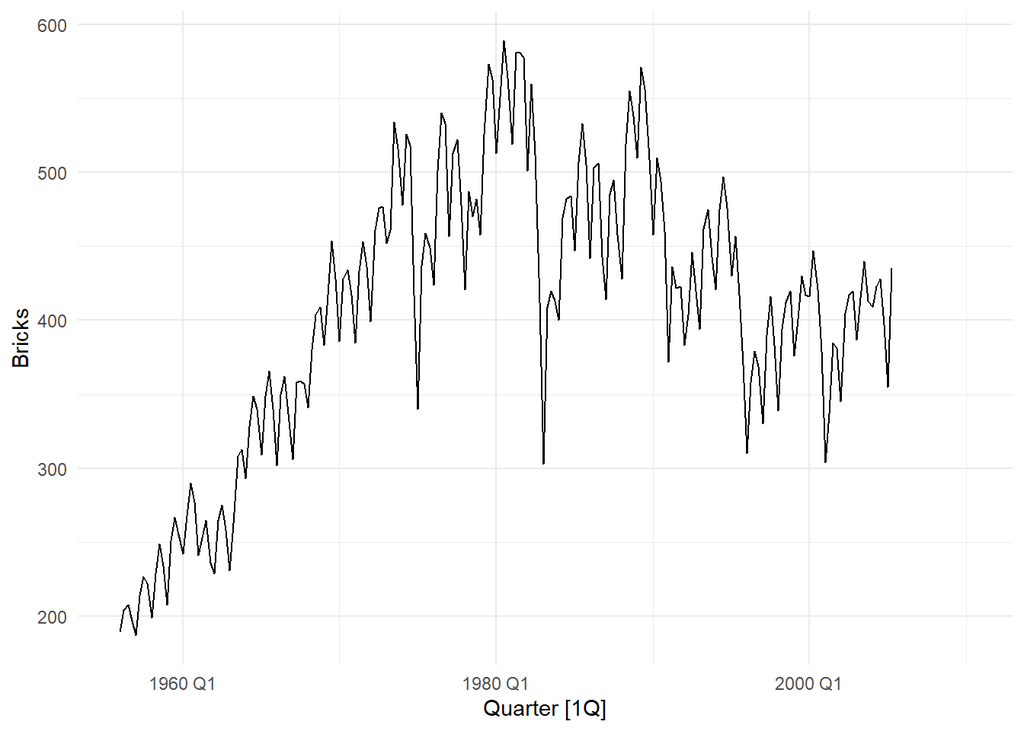

```r
aus_production %>%
    autoplot(Bricks)
```

**Season**

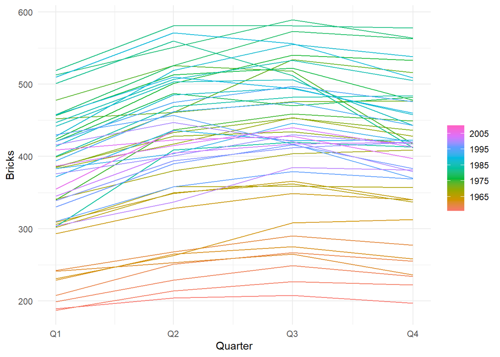

```r
aus_production %>%
    gg_season(Bricks)
```

**Sub-series**

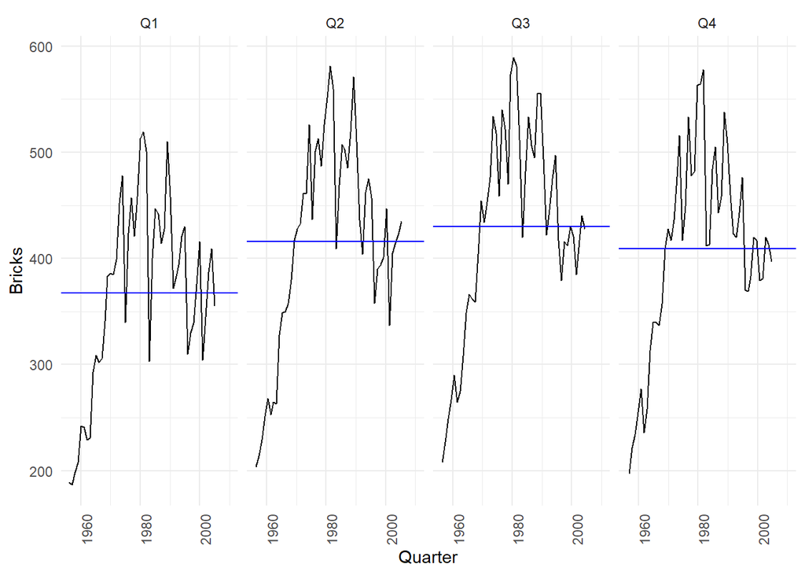

```r
aus_production %>%
    gg_subseries(Bricks)
```

**Lag**

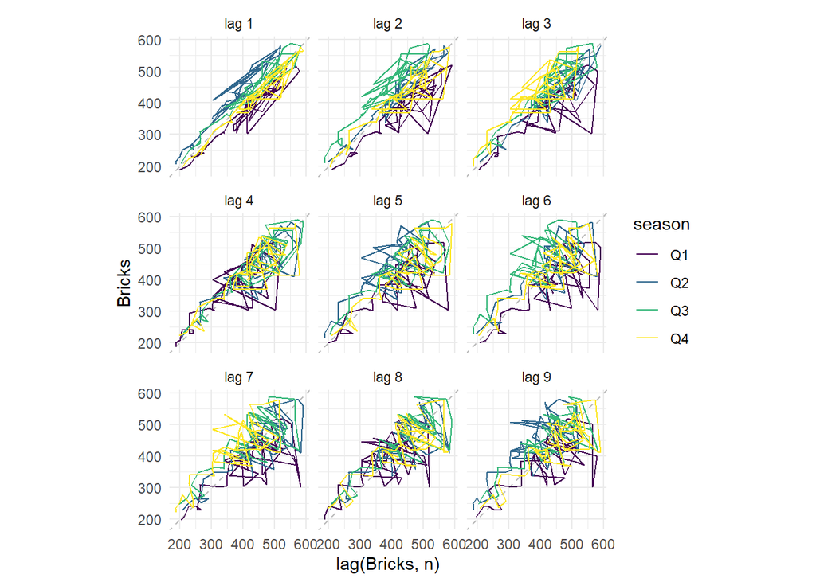

```r
aus_production %>%
    gg_lag(Bricks)
```

**Autocorrelation**

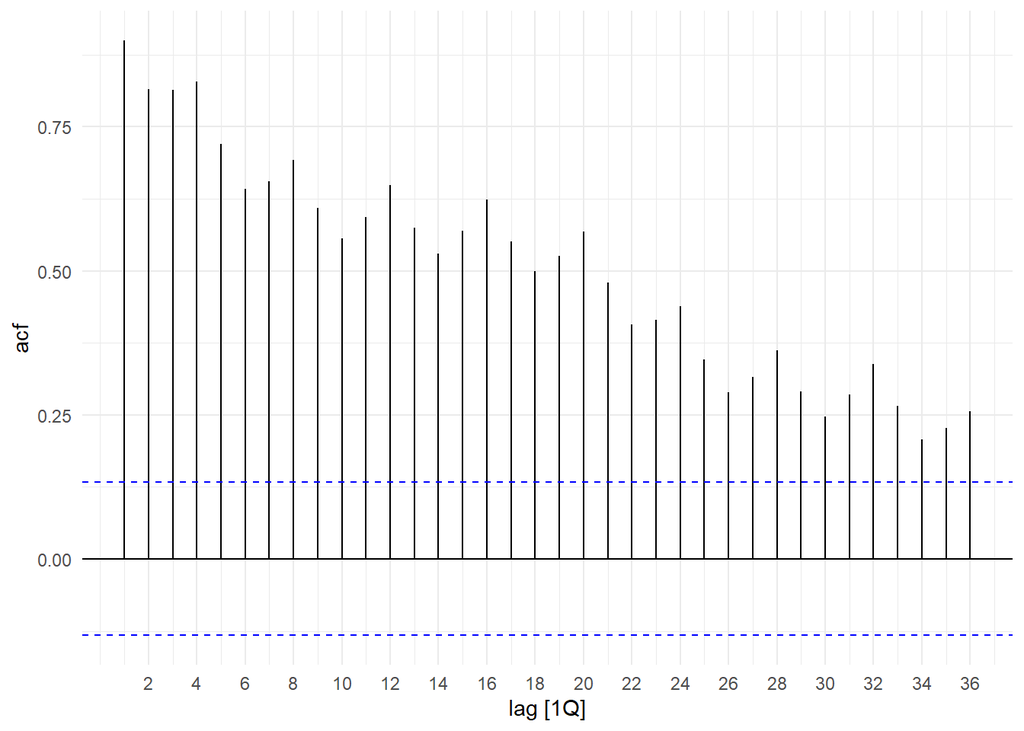

```r
aus_production %>%
    ACF(Bricks, lag_max=36) %>%
    autoplot()
```

# Q10

# Q11

The aus_livestock data contains the monthly total number of pigs slaughtered in Victoria, Australia, from Jul 1972 to Dec 2018. Use `filter()` to extract pig slaughters in Victoria between 1990 and 1995. Use `autoplot()` and `ACF()` for this data. How do they differ from white noise? If a longer period of data is used, what difference does it make to the ACF?

**Filtered data**

```r
aus_pigs <- aus_livestock %>%
    filter(Animal == "Pigs") %>%
    filter(year(Month) >= 1990 & year(Month) <= 1995)
```

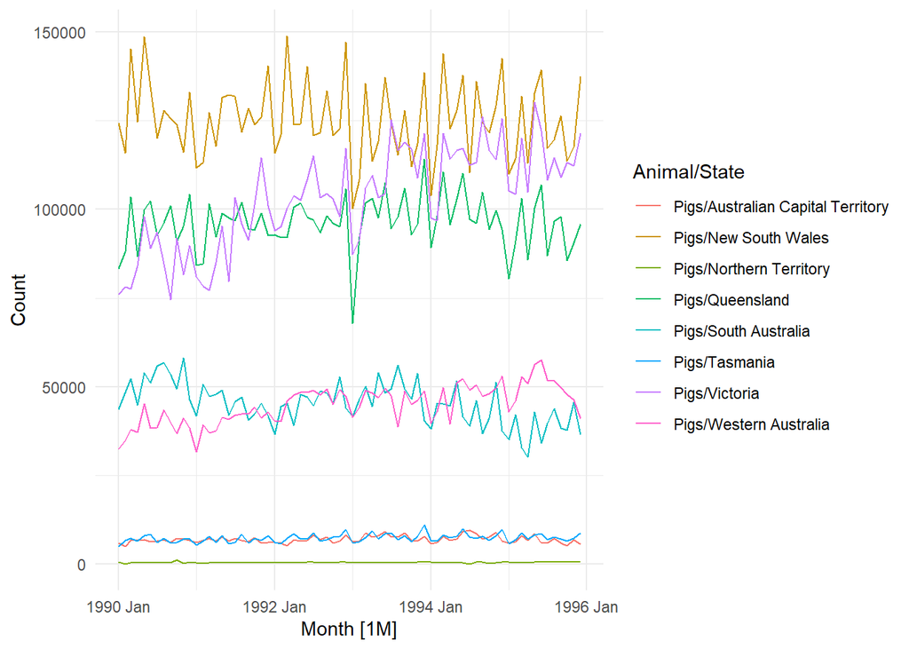

```r
aus_pigs %>%
    autoplot(Count)
```

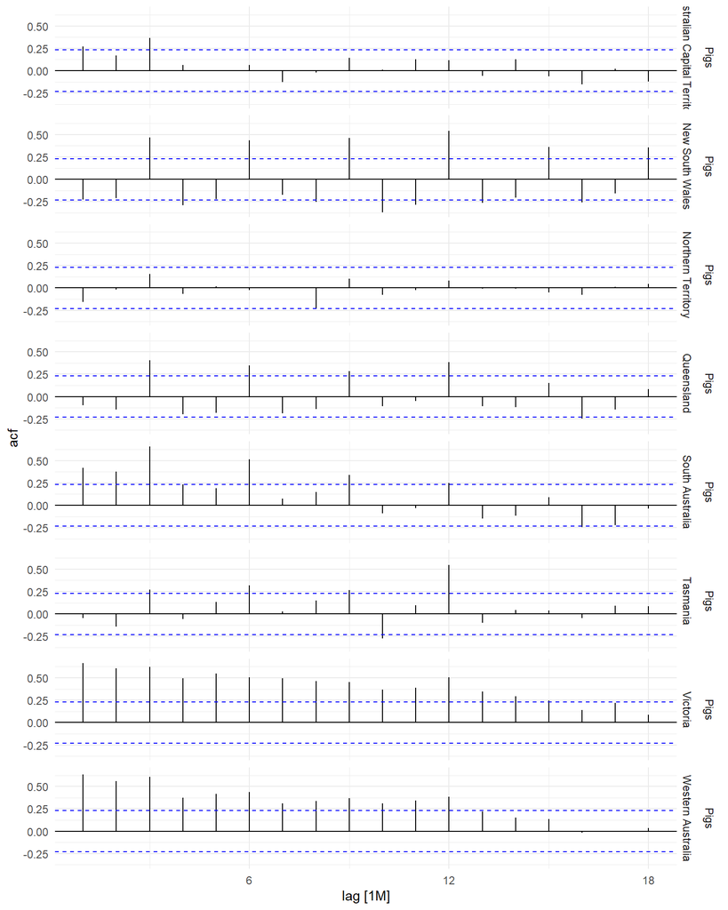

```r
aus_pigs %>%
    ACF(Count) %>%
    autoplot()
```

**Unfiltered data**

We can better see the trend with longer lags.

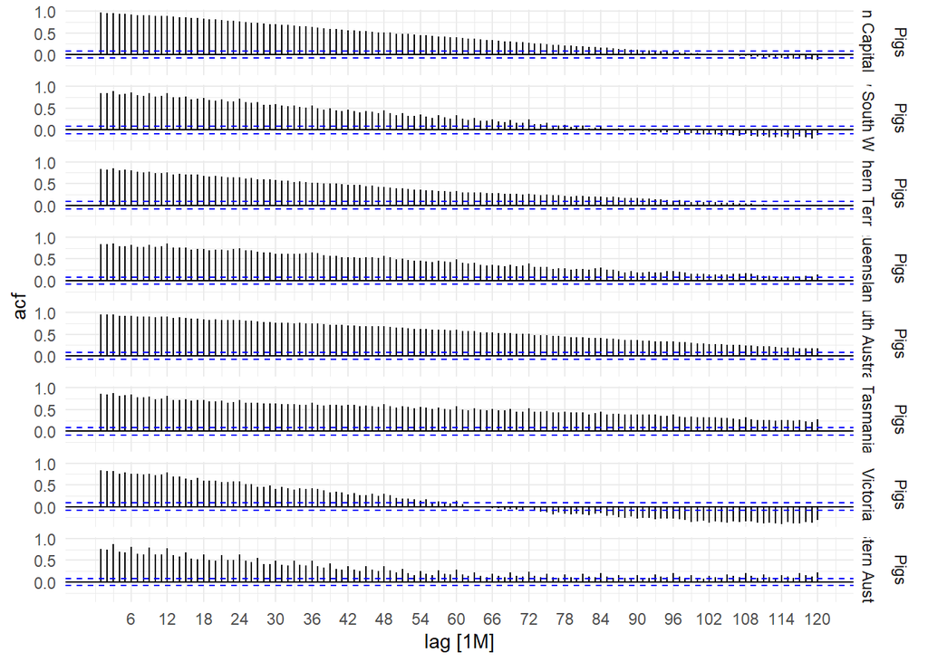

```r
aus_livestock %>%
    filter(Animal == "Pigs") %>%
    ACF(Count, lag_max=120) %>%
    autoplot()
```

# Q12

- Use the following code to compute the daily changes in Google closing stock prices.

```r
dgoog <- gafa_stock %>%
  filter(Symbol == "GOOG", year(Date) >= 2018) %>%
  mutate(trading_day = row_number()) %>%
  update_tsibble(index = trading_day, regular = TRUE) %>%
  mutate(diff = difference(Close))
```

- Why was it necessary to re-index the tsibble?

Because `dgoog` will not change the index from `Date` unless instructed otherwise. Let’s see the difference in the index with and without `update_tsibble`.

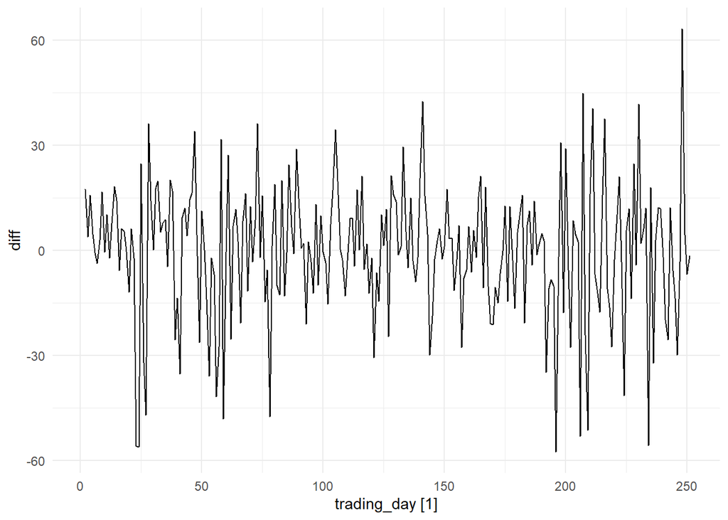

```r
# with update_tsibble
dgoog %>%
    autoplot(diff)
```

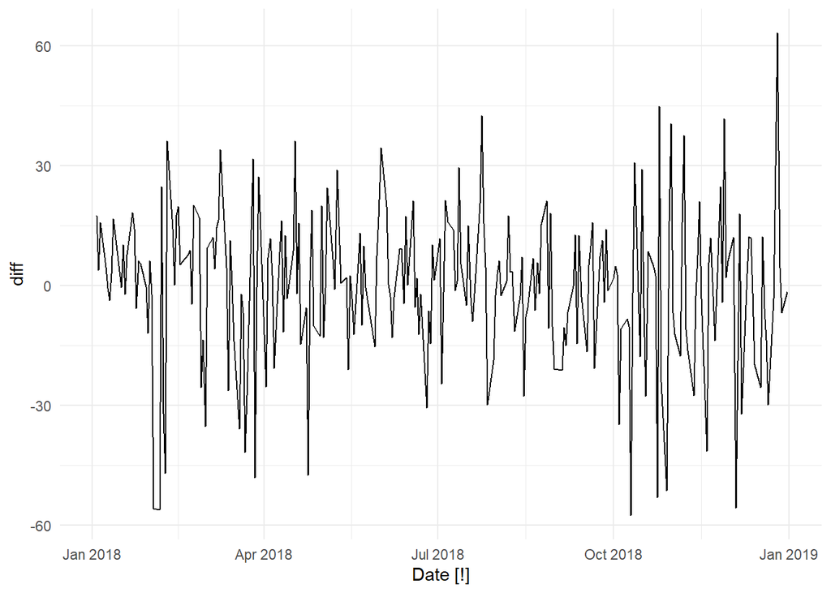

```r
# without update tsibble
gafa_stock %>%
  filter(Symbol == "GOOG", year(Date) >= 2018) %>%
  mutate(trading_day = row_number()) %>%
  mutate(diff = difference(Close)) %>%
  autoplot(diff)
```

- Plot these differences and their ACF.

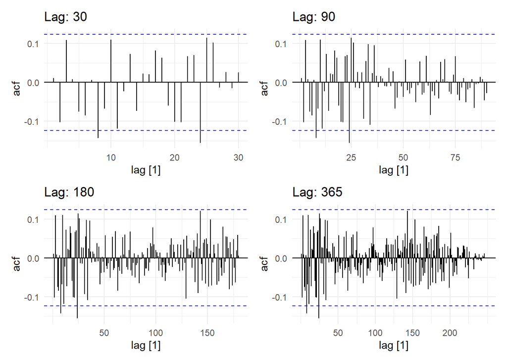

```r
plots <- lapply(c(30, 90, 180, 365), function(lag){
    dgoog %>%
    ACF(diff, lag_max = lag) %>%
    autoplot() +
    labs(title = paste("Lag:", lag))
})
wrap_plots(plots)
```

- Do the changes in the stock prices look like white noise?

Yes, no clear pattern in autocorrelation. As discussed in the [white noise](https://otexts.com/fpp3/wn.html) section, most spikes lie within the blue dashed lines.